# Part I - (Ford GoBike Dataset Analysis)

## by (Ugochukwu Ayomide Onyebuchi)

## Introduction

This data set includes information about individual rides made in a bike-sharing system covering the greater San Francisco Bay area. This data covers the period of February in 2019.

## Preliminary Wrangling

```python
# import all packages and set plots to be embedded inline
import numpy as np
import pandas as pd
import matplotlib.pyplot as plt
import seaborn as sb

%matplotlib inline
```

```python
# Load in dataset
df = pd.read_csv('201902-fordgobike-tripdata.csv')
```

```python
# Let's have a look at the shape of the dataset
df.shape
```

```
(183412, 16)
```

```python
# We can look at a section of the table
df.head(10)
```

|  | duration_sec | start_time | end_time | start_station_id | start_station_name | start_station_latitude | start_station_longitude | end_station_id | end_station_name | end_station_latitude | end_station_longitude | bike_id | user_type | member_birth_year | member_gender | bike_share_for_all_trip |
| --- | --- | --- | --- | --- | --- | --- | --- | --- | --- | --- | --- | --- | --- | --- | --- | --- |
| 0 | 52185 | 2019-02-28 17:32:10.1450 | 2019-03-01 08:01:55.9750 | 21.0 | Montgomery St BART Station (Market St at 2nd St) | 37.789625 | -122.400811 | 13.0 | Commercial St at Montgomery St | 37.794231 | -122.402923 | 4902 | Customer | 1984.0 | Male | No |
| 1 | 42521 | 2019-02-28 18:53:21.7890 | 2019-03-01 06:42:03.0560 | 23.0 | The Embarcadero at Steuart St | 37.791464 | -122.391034 | 81.0 | Berry St at 4th St | 37.775880 | -122.393170 | 2535 | Customer | NaN | NaN | No |
| 2 | 61854 | 2019-02-28 12:13:13.2180 | 2019-03-01 05:24:08.1460 | 86.0 | Market St at Dolores St | 37.769305 | -122.426826 | 3.0 | Powell St BART Station (Market St at 4th St) | 37.786375 | -122.404904 | 5905 | Customer | 1972.0 | Male | No |
| 3 | 36490 | 2019-02-28 17:54:26.0100 | 2019-03-01 04:02:36.8420 | 375.0 | Grove St at Masonic Ave | 37.774836 | -122.446546 | 70.0 | Central Ave at Fell St | 37.773311 | -122.444293 | 6638 | Subscriber | 1989.0 | Other | No |
| 4 | 1585 | 2019-02-28 23:54:18.5490 | 2019-03-01 00:20:44.0740 | 7.0 | Frank H Ogawa Plaza | 37.804562 | -122.271738 | 222.0 | 10th Ave at E 15th St | 37.792714 | -122.248780 | 4898 | Subscriber | 1974.0 | Male | Yes |
| 5 | 1793 | 2019-02-28 23:49:58.6320 | 2019-03-01 00:19:51.7600 | 93.0 | 4th St at Mission Bay Blvd S | 37.770407 | -122.391198 | 323.0 | Broadway at Kearny | 37.798014 | -122.405950 | 5200 | Subscriber | 1959.0 | Male | No |
| 6 | 1147 | 2019-02-28 23:55:35.1040 | 2019-03-01 00:14:42.5880 | 300.0 | Palm St at Willow St | 37.317298 | -121.884995 | 312.0 | San Jose Diridon Station | 37.329732 | -121.901782 | 3803 | Subscriber | 1983.0 | Female | No |
| 7 | 1615 | 2019-02-28 23:41:06.7660 | 2019-03-01 00:08:02.7560 | 10.0 | Washington St at Kearny St | 37.795393 | -122.404770 | 127.0 | Valencia St at 21st St | 37.756708 | -122.421025 | 6329 | Subscriber | 1989.0 | Male | No |
| 8 | 1570 | 2019-02-28 23:41:48.7900 | 2019-03-01 00:07:59.7150 | 10.0 | Washington St at Kearny St | 37.795393 | -122.404770 | 127.0 | Valencia St at 21st St | 37.756708 | -122.421025 | 6548 | Subscriber | 1988.0 | Other | No |
| 9 | 1049 | 2019-02-28 23:49:47.6990 | 2019-03-01 00:07:17.0250 | 19.0 | Post St at Kearny St | 37.788975 | -122.403452 | 121.0 | Mission Playground | 37.759210 | -122.421339 | 6488 | Subscriber | 1992.0 | Male | No |

```python
# Let's also have a look at the variables and their types in this dataset
df.info()
```

```
<class 'pandas.core.frame.DataFrame'>
RangeIndex: 183412 entries, 0 to 183411
Data columns (total 16 columns):
 #   Column                   Non-Null Count   Dtype
---  ------                   --------------   -----
 0   duration_sec             183412 non-null  int64
 1   start_time               183412 non-null  object
 2   end_time                 183412 non-null  object
 3   start_station_id         183215 non-null  float64
 4   start_station_name       183215 non-null  object
 5   start_station_latitude   183412 non-null  float64
 6   start_station_longitude  183412 non-null  float64
 7   end_station_id           183215 non-null  float64
 8   end_station_name         183215 non-null  object
 9   end_station_latitude     183412 non-null  float64
 10  end_station_longitude    183412 non-null  float64
 11  bike_id                  183412 non-null  int64
 12  user_type                183412 non-null  object
 13  member_birth_year        175147 non-null  float64
 14  member_gender            175147 non-null  object
 15  bike_share_for_all_trip  183412 non-null  object
dtypes: float64(7), int64(2), object(7)
memory usage: 22.4+ MB
```

##### Some issues are quickly noticed

- Wrong data typing [start_time, end_time, start_station_id, end_station_id, user_type, member_birth_year, member_gender, bike_share_for_all_trip]
- Missing values [start_station_id, start_station_name, end_station_id, end_station_name, member_birth_year, memeber_gender]

`Fixing missing values`

##### Well for start_station_id and end_station_id, we unfortunately won't be able to get them now, and we don't really need them, so we can drop them

```python
df.drop(['start_station_id', 'end_station_id'], axis=1, inplace=True)
```

##### For start_station_name, and end_station_name by geolocating their latitudes and longitudes, we could use a python library called geopy

```python
# !pip install geopy
```

```python
from geopy.geocoders import Nominatim
```

```python
# Example Usage of GeoPy [Statue of Liberty]
geolocator = Nominatim(user_agent="location finder")

# Here we put in the latitude and longitude of the Statue of Liberty
location = geolocator.reverse("40.6892, -74.044502")
print(location.address)
```

```
Statue of Liberty, Flagpole Plaza, Manhattan Community Board 1, Manhattan, New York County, City of New York, New York, 10004, United States
```

```python
# This cell takes a while to run
# Here we select records with out start_station_name and fill with the address gotten from geo.py
# station_cols = ['start_station_name', 'end_station_name']

# mask = df[station_cols].isnull().any(axis=1)
# no_names = df[mask]

# # Fill start_station_name
# start_loc_cols = ['start_station_latitude', 'start_station_longitude']
# df.loc[mask, 'start_station_name'] = no_names[start_loc_cols].apply(
#     lambda row: geolocator.reverse(
#         f"{row['start_station_latitude']}, {row['start_station_longitude']}").address, axis=1)

# # Fill end_station_name
# end_loc_cols = ['end_station_latitude', 'end_station_longitude']
# df.loc[mask, 'end_station_name'] = no_names[end_loc_cols].apply(
#     lambda row: geolocator.reverse(
#         f"{row['end_station_latitude']}, {row['end_station_longitude']}").address, axis=1)
```

##### On further observation of the member_birth_year and member_gender. The missing values seem to be MCR (Missing Completely at Random). We could drop them

```python
missing_gender_and_age = df[df['member_birth_year'].isnull() | df['member_gender'].isnull()]
missing_gender_and_age
```

|  | duration_sec | start_time | end_time | start_station_name | start_station_latitude | start_station_longitude | end_station_name | end_station_latitude | end_station_longitude | bike_id | user_type | member_birth_year | member_gender | bike_share_for_all_trip |
| --- | --- | --- | --- | --- | --- | --- | --- | --- | --- | --- | --- | --- | --- | --- |
| 1 | 42521 | 2019-02-28 18:53:21.7890 | 2019-03-01 06:42:03.0560 | The Embarcadero at Steuart St | 37.791464 | -122.391034 | Berry St at 4th St | 37.775880 | -122.393170 | 2535 | Customer | NaN | NaN | No |
| 13 | 915 | 2019-02-28 23:49:06.0620 | 2019-03-01 00:04:21.8670 | Channing Way at Shattuck Ave | 37.865847 | -122.267443 | Shattuck Ave at Hearst Ave | 37.873676 | -122.268487 | 5101 | Subscriber | NaN | NaN | No |
| 28 | 650 | 2019-02-28 23:43:27.5030 | 2019-02-28 23:54:18.4510 | University Ave at Oxford St | 37.872355 | -122.266447 | Channing Way at San Pablo Ave | 37.862827 | -122.290231 | 4784 | Customer | NaN | NaN | No |
| 53 | 3418 | 2019-02-28 22:41:16.3620 | 2019-02-28 23:38:14.3630 | Davis St at Jackson St | 37.797280 | -122.398436 | Davis St at Jackson St | 37.797280 | -122.398436 | 319 | Customer | NaN | NaN | No |
| 65 | 926 | 2019-02-28 23:17:05.8530 | 2019-02-28 23:32:32.6820 | Commercial St at Montgomery St | 37.794231 | -122.402923 | Berry St at 4th St | 37.775880 | -122.393170 | 2951 | Subscriber | NaN | NaN | No |
| ... | ... | ... | ... | ... | ... | ... | ... | ... | ... | ... | ... | ... | ... | ... |
| 183354 | 449 | 2019-02-01 01:35:07.6630 | 2019-02-01 01:42:36.8780 | Shattuck Ave at Hearst Ave | 37.873676 | -122.268487 | Haste St at College Ave | 37.866418 | -122.253799 | 5430 | Customer | NaN | NaN | No |
| 183356 | 795 | 2019-02-01 01:25:50.3660 | 2019-02-01 01:39:05.9500 | Myrtle St at Polk St | 37.785434 | -122.419622 | 20th St at Bryant St | 37.759200 | -122.409851 | 5400 | Subscriber | NaN | NaN | No |
| 183363 | 673 | 2019-02-01 01:12:24.4200 | 2019-02-01 01:23:37.6450 | Market St at Franklin St | 37.773793 | -122.421239 | Valencia St at 22nd St | 37.755213 | -122.420975 | 5166 | Customer | NaN | NaN | No |
| 183371 | 196 | 2019-02-01 01:08:38.6410 | 2019-02-01 01:11:54.9490 | Market St at 10th St | 37.776619 | -122.417385 | Market St at Franklin St | 37.773793 | -122.421239 | 2395 | Customer | NaN | NaN | No |
| 183402 | 122 | 2019-02-01 00:17:32.2580 | 2019-02-01 00:19:34.9380 | 18th St at Noe St | 37.761047 | -122.432642 | Mission Dolores Park | 37.761420 | -122.426435 | 4326 | Subscriber | NaN | NaN | No |

8265 rows × 14 columns

```python
# Drop rows with missing values
df.dropna(inplace=True)
```

```python
df.info()
```

```
<class 'pandas.core.frame.DataFrame'>
Int64Index: 175147 entries, 0 to 183411
Data columns (total 14 columns):
 #   Column                   Non-Null Count   Dtype
---  ------                   --------------   -----
 0   duration_sec             175147 non-null  int64
 1   start_time               175147 non-null  object
 2   end_time                 175147 non-null  object
 3   start_station_name       175147 non-null  object
 4   start_station_latitude   175147 non-null  float64
 5   start_station_longitude  175147 non-null  float64
 6   end_station_name         175147 non-null  object
 7   end_station_latitude     175147 non-null  float64
 8   end_station_longitude    175147 non-null  float64
 9   bike_id                  175147 non-null  int64
 10  user_type                175147 non-null  object
 11  member_birth_year        175147 non-null  float64
 12  member_gender            175147 non-null  object
 13  bike_share_for_all_trip  175147 non-null  object
dtypes: float64(5), int64(2), object(7)
memory usage: 20.0+ MB
```

`Fixing Bad Typing`

#### Code

```python
df[['start_time', 'end_time']] = df[['start_time', 'end_time']].apply(pd.to_datetime)

df['member_birth_year'] = df['member_birth_year'].astype('int')

df[['user_type', 'member_gender', 'bike_share_for_all_trip']] = df[['user_type', 'member_gender', 'bike_share_for_all_trip']].astype('category')
```

#### Test

```python
df.dtypes
```

```
duration_sec                        int64
start_time                 datetime64[ns]
end_time                   datetime64[ns]
start_station_name                 object
start_station_latitude            float64
start_station_longitude           float64
end_station_name                   object
end_station_latitude              float64
end_station_longitude             float64
bike_id                             int64
user_type                        category
member_birth_year                   int32
member_gender                    category
bike_share_for_all_trip          category
dtype: object
```

```python
# Look at unique values per variables
df.nunique()
```

```
duration_sec                 4432
start_time                 175136
end_time                   175134
start_station_name            343
start_station_latitude        334
start_station_longitude       335
end_station_name              346
end_station_latitude          335
end_station_longitude         335
bike_id                      4635
user_type                       2
member_birth_year              75
member_gender                   3
bike_share_for_all_trip         2
dtype: int64
```

```python
# A quick descriptive statistics for numeric variables
df.describe()
```

|  | duration_sec | start_station_latitude | start_station_longitude | end_station_latitude | end_station_longitude | bike_id | member_birth_year |
| --- | --- | --- | --- | --- | --- | --- | --- |
| count | 175147.000000 | 175147.000000 | 175147.000000 | 175147.000000 | 175147.000000 | 175147.000000 | 175147.000000 |
| mean | 704.211845 | 37.770814 | -122.351305 | 37.771007 | -122.350881 | 4482.252639 | 1984.806437 |
| std | 1641.608363 | 0.101070 | 0.118453 | 0.100978 | 0.118018 | 1658.303747 | 10.116689 |
| min | 61.000000 | 37.317298 | -122.453704 | 37.317298 | -122.453704 | 11.000000 | 1878.000000 |
| 25% | 323.000000 | 37.770407 | -122.411901 | 37.770407 | -122.411647 | 3802.000000 | 1980.000000 |
| 50% | 510.000000 | 37.780760 | -122.398279 | 37.781010 | -122.397405 | 4959.000000 | 1987.000000 |
| 75% | 789.000000 | 37.797320 | -122.283093 | 37.797673 | -122.285171 | 5505.000000 | 1992.000000 |
| max | 84548.000000 | 37.880222 | -121.874119 | 37.880222 | -121.874119 | 6645.000000 | 2001.000000 |

```python
# Check for duplicates
df.duplicated().sum()
```

```
0
```

`Well, our datset is free of duplicates, yay`

### What is the structure of your dataset?

The dataset contains about 183,412 Bike-Sharing trips records with 16 features.

### What is/are the main feature(s) of interest in your dataset?

Some interesting features I hope to mainly explore include:

- Duration (duration_sec)
- Gender of users (member_gender)
- Age of users (member_birth_year)
- User Types (subscriber or customer)
- Station Name (start_station_name, end_station_name)

### What features in the dataset do you think will help support your investigation into your feature(s) of interest?

- Gender of users (member_gender)
- Age of users (member_birth_year)
- User Types (subscriber or customer)
- Station Name (start_station_name, end_station_name)

## Univariate Exploration

### Categorical Variables

We explore the categorical variables first using bar charts.

```python
# General use

color1 = sb.color_palette("rocket")[0]
# Let's define a function we can reuse in other places
def plotBar(data, x, color, xlabel, ylabel, title):
    sb.countplot(data=data, x=x, color=color)
    plt.xlabel(xlabel)
    plt.ylabel(ylabel)
    plt.title(title);
```

##### What gender makes the most trips ?

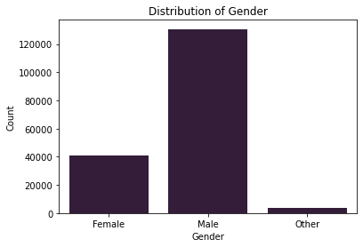

```python
plotBar(df, x='member_gender', color=color1, xlabel='Gender',
        ylabel='Count', title='Distribution of Gender')
```

`Most Bike-Share riders are Male. It's also interesting to note, some of the users were neither male or female, shows the Bike-Share is acessible to everyone.`

##### What user type takes more trip ?

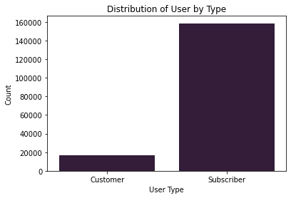

```python
plotBar(df, x='user_type', color=color1, xlabel='User Type',
        ylabel='Count', title='Distribution of User by Type')
```

`Majority of the users are subscribers`

##### Do users bike-share throughout the trip ?

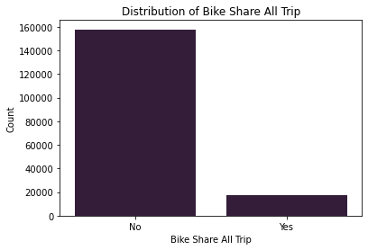

```python
plotBar(df, x='bike_share_for_all_trip', color=color1,
        xlabel='Bike Share All Trip', ylabel='Count',
        title='Distribution of Bike Share All Trip')
```

`A large majority of the trips didn't have the bike shared throughout the trip.`

#### What day of the week had the highest amount of trips ?

###### First, let's create a day_of_the_week column to hold the days of the week of each trip, then we also categorize and order it.

```python
df['day_of_week'] = df['start_time'].dt.day_name()

ordered_var = pd.api.types.CategoricalDtype(ordered = True,
                                                categories = ['Monday','Tuesday','Wednesday','Thursday','Friday','Saturday', 'Sunday'])
df['day_of_week'] = df['day_of_week'].astype(ordered_var)
```

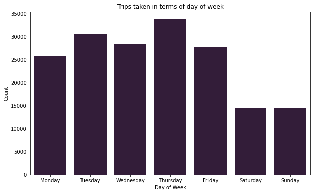

```python
plt.figure(figsize=[10, 6])
sb.countplot(data=df, x=df['day_of_week'], color=color1)
plt.xlabel('Day of Week')
plt.ylabel('Count')
plt.title('Trips taken in terms of day of week');
```

`Most trips seem to happen on a Thursday, and we can also see that there are lesser trips on the weekends`

#### What hour of the day had the highest amount of trips ?

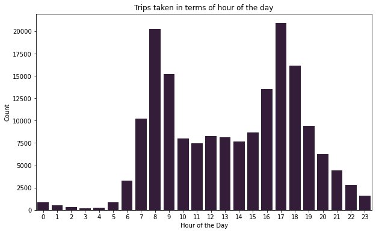

```python
plt.figure(figsize=[10, 6])
sb.countplot(data=df, x=df['start_time'].dt.hour, color=color1)
plt.xlabel('Hour of the Day')
plt.ylabel('Count')
plt.title('Trips taken in terms of hour of the day');
```

`Well, most trips seem to happen around the 17th hour(5:00pm) and closely following 8th hour(8:00am), coincidentally that's work hour starting and ending hour 🤔`

##### Finally, we look at the total amount of trips per station

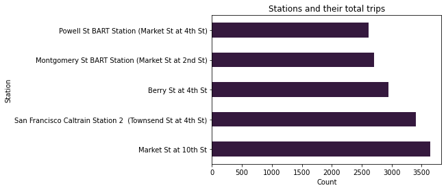

```python
data = df['start_station_name'].value_counts()[:5]
data.plot(kind='barh', title='Stations and their total trips', color=color1)
plt.xlabel('Count')
plt.ylabel('Station');
```

### Numerical Variables Exploration

Here we explore the numeric variables

```python
color2 = sb.color_palette('Blues')[4]
```

##### How long do most trips take ?

Duration represents the seconds spent the whole trip

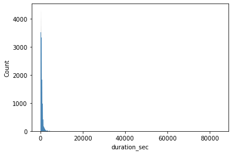

```python
sb.histplot(data=df, x='duration_sec', color=color2);
```

`The distribution looks highly skewed and majority of the data points lie in between 0-2000, we will need to apply a logarithmic scale to follow a mormal distribution`

```python
# Let's have a look at the log of describe() on the duration_sec column
# The values here will help us in preparing our bins
np.log10(df['duration_sec'].describe())
```

```
count    5.243403
mean     2.847703
std      3.215270
min      1.785330
25%      2.509203
50%      2.707570
75%      2.897077
max      4.927103
Name: duration_sec, dtype: float64
```

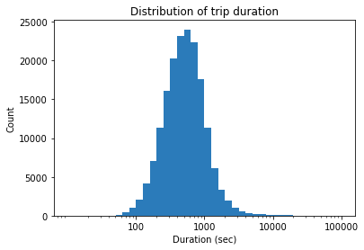

```python
# Get the ticks for bins between [0 - maximum duration]
bins = 10 ** np.arange(1, 5+0.1, 0.1)

# Generate the x-ticks you want to apply
ticks = [100, 1000, 10000, 100000]
# Convert ticks into string values, to be displayed dlong the x-axis
labels = ['{}'.format(v) for v in ticks]

# Plot the histogram
plt.hist(data=df, x='duration_sec', bins=bins, color=color2);

plt.xscale('log')
plt.xlabel('Duration (sec)')
plt.ylabel('Count')
plt.title('Distribution of trip duration')

# Apply x-ticks
plt.xticks(ticks, labels);
```

#### What age group often bike-shares ?

To answer this question, we will need to derive the ages from the member_birth_year column.

##### Code

```python
# Create column for age
df['age'] = 2019 - df['member_birth_year']
```

##### Test

```python
df[['member_birth_year', 'age']][:5]
```

|  | member_birth_year | age |
| --- | --- | --- |
| 0 | 1984 | 35 |
| 2 | 1972 | 47 |
| 3 | 1989 | 30 |
| 4 | 1974 | 45 |
| 5 | 1959 | 60 |

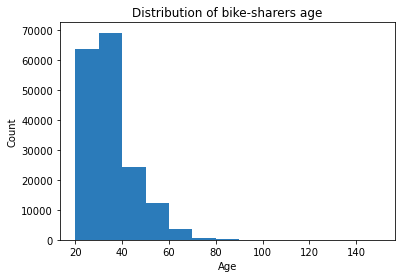

```python
binsize = 10
bins = np.arange(20, df.age.max()+binsize, binsize)
plt.hist(data=df, x='age', color=color2, bins=bins)
plt.xlabel('Age')
plt.ylabel('Count')
plt.title('Distribution of bike-sharers age');
```

`Most users fall in the 30-40 age group`

### Of the features you investigated, were there any unusual distributions? Did you perform any operations on the data to tidy, adjust, or change the form of the data? If so, why did you do this?

The duration_sec variable was heavily skewed, as most data points were packed at the low endings on the left, I had to apply a log scaling on the axis to normalize the distribution

## Bivariate Exploration

##### Generally, how does each variable correlates with one another ?

##### I use seaborn's heatmap method to have a quick overview of how each variables correlate.

```python
# Only numeric variables
numeric_vars = ['age', 'duration_sec']
```

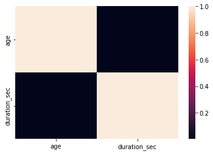

```python
sb.heatmap(df[numeric_vars].corr());
```

`There doesn't seem to be a linear relationship between age and duration_sec, let's keep exploring`

##### Next we look at the distribution of the categorical variables against duration

- Selected a random sample from the dataset to visualize here to reduce noise and improve load time
- Set a limit on the yaxis to 5000 to reduce noise

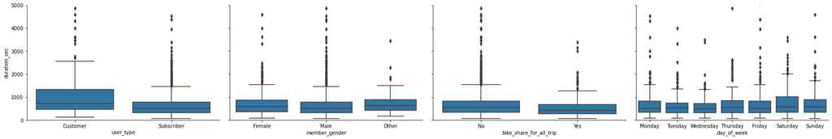

```python
categoric_vars = ['user_type', 'member_gender', 'bike_share_for_all_trip', 'day_of_week']
trips_samp = df.sample(n=2000, replace = False)

def boxgrid(x, y, **kwargs):
    """ Quick hack for creating box plots with seaborn's PairGrid. """
    default_color = sb.color_palette()[0]
    sb.boxplot(x=x, y=y, color=default_color)

plt.figure(figsize = [10, 10]);
g = sb.PairGrid(data = trips_samp, y_vars = ['duration_sec'], x_vars = categoric_vars,
                height = 4, aspect = 1.5)
g.map(boxgrid)

plt.ylim(0, 5000);
```

- Many subscribers seem to lie below the 1000 duration mark
- The 'other' group of gender seem to have slightly higher trip durations than Males and Females
- Users that don't bike share all through the trip tend to spend more time on trips than those who bike share all through
- Weekends seem to have longer trip times

##### How much time do different age groups spend on a trip ?

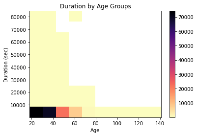

```python
plt.hist2d(data = df, x = 'age', y = 'duration_sec', cmin=0.5, cmap='magma_r')
plt.colorbar()
plt.xlabel('Age')
plt.ylabel('Duration (sec)')
plt.title('Duration by Age Groups');
```

`Most ages ride below the 10000 seconds mark, and very few above that`

##### How old are male/female/other bike-sharers ?

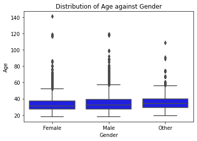

```python
sb.boxplot(data=df, x='member_gender', y='age', color='b')
plt.xlabel('Gender')
plt.ylabel('Age')
plt.title('Distribution of Age against Gender');
```

`It's a close call here, as users marked as 'other gender' tend to be older, but a little bit older than males`

##### Who spends all the trip bike sharing ?

##### I first did this, haha

I actually realised this late, I had to go do some plots again

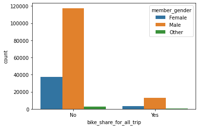

```python
sb.countplot(data=df, x='bike_share_for_all_trip', hue='member_gender');
```

`This is deceiving, since males have the largest proportion and apparently this will bias our visualization`

##### The better way to do it

Using histplot with percentage/proportion on yaxis instead of count, I used the `stat` attribute in hisplot to achieve this.

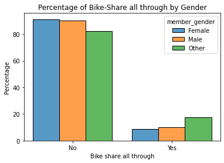

```python
sb.histplot(x = df['bike_share_for_all_trip'], hue=df['member_gender'], multiple="dodge",
                  stat = 'percent', shrink = 0.8, common_norm=False)
plt.xlabel('Bike share all through')
plt.ylabel('Percentage')
plt.title('Percentage of Bike-Share all through by Gender');
```

- Females are more likely to not bike share all through the trip than the other gender types
- The 'other' gender are more likely to bike share all through

##### How many males and females are customers or subscribers ?

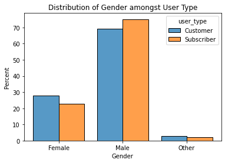

```python
sb.histplot(x = df['member_gender'], hue=df['user_type'], multiple="dodge",
                  stat = 'percent', shrink = 0.8, common_norm=False)
plt.xlabel('Gender')
plt.title('Distribution of Gender amongst User Type');
```

- Females tend to be customers than subscribers
- Males tend to be subscribers than customers
- The other group of gender also tend to be customers than subscribers

##### Who spends more time bike-sharing [Customer or Subscribers] ?

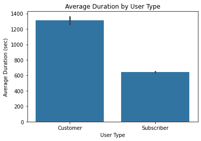

```python
color = sb.color_palette()[0]
sb.barplot(data=df, x='user_type', y='duration_sec', color=color);

plt.xlabel('User Type')
plt.ylabel('Average Duration (sec)')
plt.title('Average Duration by User Type');
```

`Customers seem to spend more time during atrip than subscribers do`

### Did you observe any interesting relationships between the other features (not the main feature(s) of interest)?

No

## Multivariate Exploration

##### Let's have a look at the relationship between user type, age and trip duration

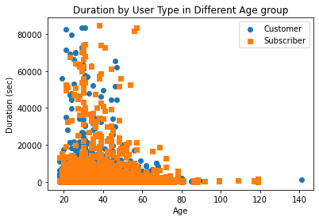

```python
# Encodings for user types
user_type_markers = [['Customer', 'o'], ['Subscriber', 's']]

for user_type, marker in user_type_markers:
    plot_data = df[df['user_type'] == user_type]
    plt.scatter(data=plot_data, x='age', y='duration_sec', marker=marker)
plt.legend(['Customer', 'Subscriber'])
plt.xlabel('Age')
plt.ylabel('Duration (sec)')
plt.title('Duration by User Type in Different Age group');
```

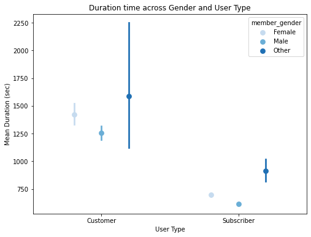

```python
fig = plt.figure(figsize = [8,6])
ax = sb.pointplot(data = df, x = 'user_type', y = 'duration_sec', hue = 'member_gender',
           palette = 'Blues', linestyles = '', dodge = 0.4)
plt.title('Duration time across Gender and User Type')
plt.ylabel('Mean Duration (sec)')
plt.xlabel('User Type');
```

- On average female customers spend around 1450 seconds on a trip, male customers spend 1250 seconds on a trip, while the 'other' gender spends the highest with about 1600 seconds on a trip
- Male subscribers on average spend a little above 600 seconds, while female subscribers spend about 700 seconds on a trip, the 'other' gender spends about 900 seconds.